# PCA & Clustering Analysis — Feature Contribution Investigation

### Script Purpose

This notebook focuses on investigating the behavior and interpretability of the **first two principal components (PC1 & PC2)** derived from Spotify audio features, with the aim of understanding how these components contribute to **genre-related structure** in the dataset.

The workflow includes:

- **Hierarchical clustering** (106 clusters) based on scaled audio features.
- **PCA transformation** for 2D projection and visual cluster separation.
- **Detection of unintended data splits** in PCA space.
- **Hypothesis testing** to identify whether:
  - Highly correlated features cause the separation (FALSE)
  - Binary features are responsible (TRUE)

🔍 The binary feature `"mode"` was identified as the **dominant factor in PC1**, leading to unnatural separation. After removing `"mode"`, the PCA visualization aligned more realistically with expected genre distributions.

Final steps include:

- Redoing PCA and clustering without `"mode"`.
- Comparing pre/post-removal visualizations and feature contributions.
- Verifying that the principal components now reflect **true musical variance** rather than binary-driven distortion.

### Imports & Setup

```python
import pandas as pd
import numpy as np
import seaborn as sns
import matplotlib.pyplot as plt
from matplotlib.patches import Patch
import matplotlib.patches as mpatches
from sklearn.preprocessing import MinMaxScaler
from sklearn.decomposition import PCA
from scipy.cluster.hierarchy import linkage, fcluster
from scipy.spatial.distance import pdist
from matplotlib.gridspec import GridSpec
```

### Load Dataset

This block loads the Spotify dataset from a Kaggle CSV file. The dataset includes tracks from three genres: MPB, Rock, and Death Metal. We'll later analyze their numerical features to identify genre-related clusters and their distribution in PCA space.

```python
df = pd.read_csv("Data for Modeling/MPBROCKMETAL_KGsubset.csv")
```

### Hierarchical Clustering Function

This function performs hierarchical clustering on a subset of numerical features from the dataset. It:

- Scales features using Min-Max normalization.
- Applies Ward's method for hierarchical clustering.
- Uses a flat clustering method to create num_clusters (default 106).
- Visualizes the clustering via a Seaborn clustermap.
- **Returns** the clustered dataframe.

*The number 106 aligns with the best-performing decision tree classifier's leaf count (97% accuracy)*

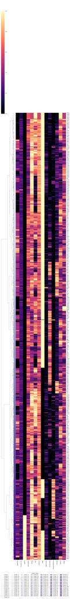

```
   popularity  duration_ms  explicit  danceability  energy  key  loudness  \
0          66       151565     False         0.765   0.497    1    -7.806
1          65        89293     False         0.720   0.422    1   -13.338
2          49       259066     False         0.632   0.651    7    -8.658
3          49       216446     False         0.610   0.420    4   -10.889
4          50       273906     False         0.580   0.330    7   -13.703

   mode  speechiness  acousticness  instrumentalness  liveness  valence  \
0     0       0.0402         0.492          0.366000    0.1430    0.457
1     0       0.0690         0.474          0.084700    0.1550    0.546
2     0       0.0401         0.756          0.000004    0.7260    0.652
3     0       0.0462         0.815          0.000000    0.1230    0.553
4     1       0.0295         0.596          0.000001    0.0849    0.373

     tempo  cluster
```

[output cut: 45 more lines]

```python
def hierarchical_clustering(df, iloc_lower, iloc_upper, num_clusters=106):
    X = df.iloc[:, iloc_lower:iloc_upper]

    scaler = MinMaxScaler()
    normalized_data = pd.DataFrame(scaler.fit_transform(X), columns=X.columns, index=X.index)

    Z = linkage(normalized_data, method='ward', metric='euclidean')

    num_clusters = 106
    clusters = fcluster(Z, num_clusters, criterion='maxclust')

    palette = sns.color_palette("Purples", num_clusters)
    cluster_to_color = {cluster: palette[i] for i, cluster in enumerate(np.unique(clusters))}
    row_colors = pd.Series(clusters, index=normalized_data.index).map(cluster_to_color)

    g = sns.clustermap(normalized_data,
                    row_linkage=Z,
                    col_cluster=False,
                    row_colors=row_colors,
                    cmap="magma",
                    figsize=(10, 80))

    legend_clusters = list(cluster_to_color.keys())
    legend_elements = [Patch(facecolor=cluster_to_color[cl], label=f'Cluster {cl}') for cl in legend_clusters]


    plt.gcf().legend(handles=legend_elements,
                    title='Cluster Colors',
                    loc='lower center',
                    ncol=7,
                    bbox_to_anchor=(0.5, -0.05))

    plt.show()

    result = X.copy()
    result['cluster'] = clusters


    print(result.head())
    return result


result = hierarchical_clustering(df,6,20 )
print(result)
```

### PCA + Clustering Visualization

This function applies `PCA to visualize clusters in 2D` (PC1 vs PC2). It:

- Performs hierarchical clustering.
- Reduces data to 2D using PCA.
- Plots a scatter plot colored by cluster IDs.
- Adds a dynamic color-coded legend for all 106 clusters.
- This helps investigate how genres are distributed in PC space.

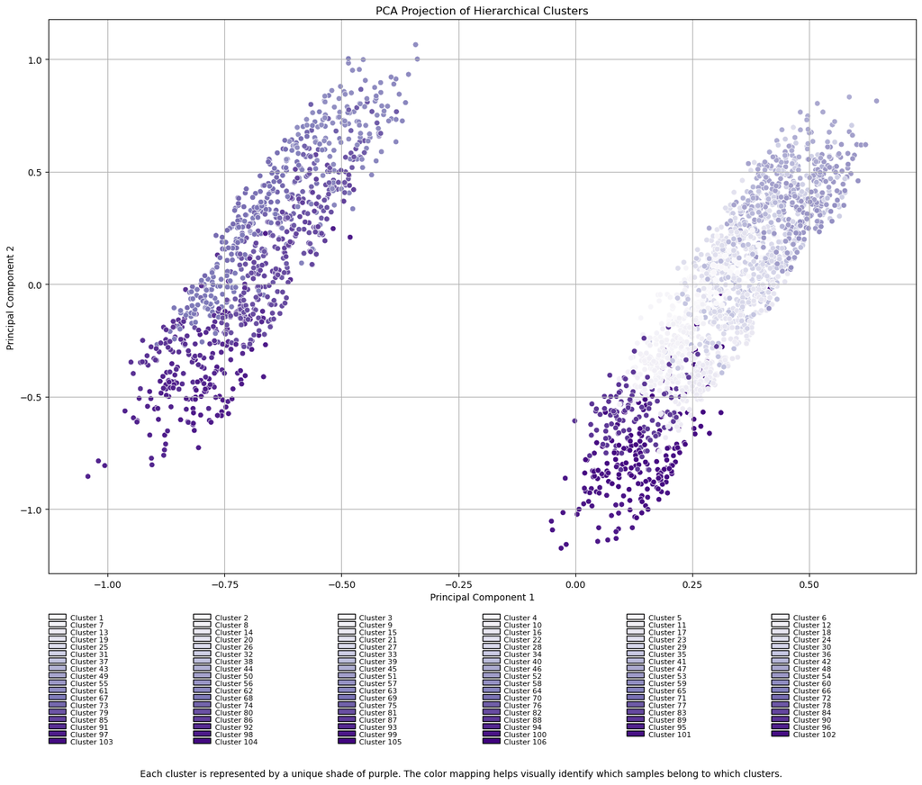

|  | PC1 | PC2 | cluster |
| --- | --- | --- | --- |
| 0 | -0.517205 | 0.462498 | 79 |
| 1 | -0.451345 | 0.638049 | 79 |
| 2 | -0.495144 | 0.722466 | 65 |
| 3 | -0.428134 | 0.813609 | 60 |
| 4 | 0.434998 | 0.448380 | 50 |
| ... | ... | ... | ... |
| 2995 | 0.281309 | -0.424130 | 16 |
| 2996 | 0.181394 | -0.440955 | 10 |
| 2997 | -0.753654 | -0.515405 | 98 |
| 2998 | 0.148060 | -0.714397 | 104 |
| 2999 | -0.866963 | -0.255016 | 90 |

3000 rows × 3 columns

```python
def plot_pca_clusters_with_legend(df, iloc_lower, iloc_upper, num_clusters=106):
    X = df.iloc[:, iloc_lower:iloc_upper]
    scaler = MinMaxScaler()
    normalized_data = pd.DataFrame(scaler.fit_transform(X), columns=X.columns, index=X.index)

    Z = linkage(normalized_data, method='ward', metric='euclidean')
    clusters = fcluster(Z, num_clusters, criterion='maxclust')
    normalized_data['cluster'] = clusters

    pca = PCA(n_components=2)
    pca_result = pca.fit_transform(normalized_data.drop(columns='cluster'))
    pca_df = pd.DataFrame(pca_result, columns=['PC1', 'PC2'], index=X.index)
    pca_df['cluster'] = clusters

    palette = sns.color_palette("Purples", num_clusters)

    fig, (ax_main, ax_legend) = plt.subplots(2, 1, figsize=(14, 12), gridspec_kw={'height_ratios': [4, 1]})

    sns.scatterplot(data=pca_df, x='PC1', y='PC2', hue='cluster', palette=palette, legend=False, ax=ax_main)
    ax_main.set_title("PCA Projection of Hierarchical Clusters")
    ax_main.set_xlabel("Principal Component 1")
    ax_main.set_ylabel("Principal Component 2")
    ax_main.grid(True)

    ax_legend.axis('off')
    n_cols = 6
    n_rows = -(-num_clusters // n_cols)

    x_spacing = 1.0 / n_cols
    y_spacing = 1.0 / (n_rows + 1)

    for i in range(num_clusters):
        col = i % n_cols
        row = i // n_cols
        x = col * x_spacing
        y = 1 - (row + 1) * y_spacing

        color_patch = mpatches.Rectangle((x, y), 0.02, 0.04, transform=ax_legend.transAxes,
                                         facecolor=palette[i], edgecolor='black')
        ax_legend.add_patch(color_patch)
        ax_legend.text(x + 0.025, y + 0.01, f'Cluster {i + 1}', transform=ax_legend.transAxes,
                       fontsize=8, va='center')


    plt.figtext(0.5, 0.02, "Each cluster is represented by a unique shade of purple. The color mapping helps visually identify which samples belong to which clusters.",
                ha='center', fontsize=10)

    plt.tight_layout(rect=[0, 0.04, 1, 1])
    plt.show()

    return pca_df


pca_df =plot_pca_clusters_with_legend(df,6,20)
pca_df
```

### Merge Clustering and PCA Results

This block merges PCA results with hierarchical cluster labels for deeper analysis. It also computes a signed Euclidean distance from a decision boundary in the PCA space, allowing us to segment data visually into two groups based on PC1.

```python
df_cluster_PCA = pd.merge(result, pca_df, left_index=True, right_index=True)
df_cluster_PCA.drop(columns=["cluster_y"], inplace=True)
df_cluster_PCA.reset_index(inplace=True)

pc1 = df_cluster_PCA["PC1"].tolist()
pc2 = df_cluster_PCA["PC2"].tolist()

def get_pca_distance_with_x_sign(x, y, boundary_x=-0.25, boundary_y=0):
    distance = np.sqrt((x - boundary_x)**2 + (y - boundary_y)**2)
    return distance if x > boundary_x else -distance

pc_distances = [get_pca_distance_with_x_sign(x, y) for x, y in zip(pc1, pc2)]
df_cluster_PCA["PCA_EuclidianDist(Xsign)"] = pc_distances

def add_first_boundary_group(df, distance_column="PCA_EuclidianDist(Xsign)"):
    df["1th_Boundary"] = df[distance_column].apply(lambda x: -1 if x < 0 else 1)
    return df

df_cluster_PCA_gp = add_first_boundary_group(df_cluster_PCA)
df_cluster_PCA_gp = pd.merge(df["track_genre"], df_cluster_PCA_gp, left_index=True, right_index=True)

groupA = df_cluster_PCA_gp[df_cluster_PCA_gp["1th_Boundary"] == -1]
groupB = df_cluster_PCA_gp[df_cluster_PCA_gp["1th_Boundary"] == 1]
```

### Plot Feature Comparisons (Group A vs B)

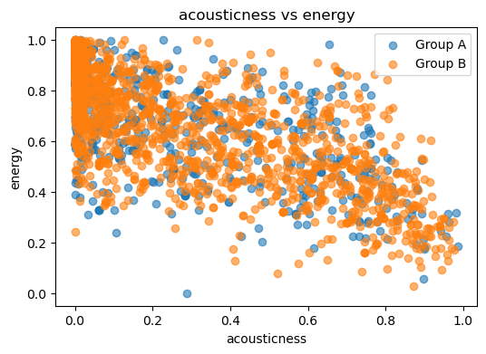

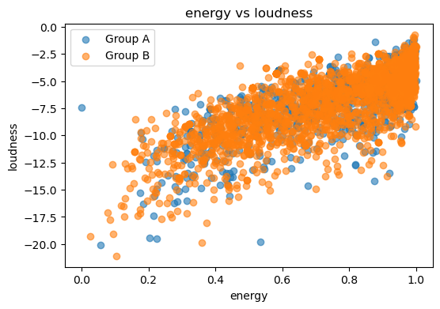

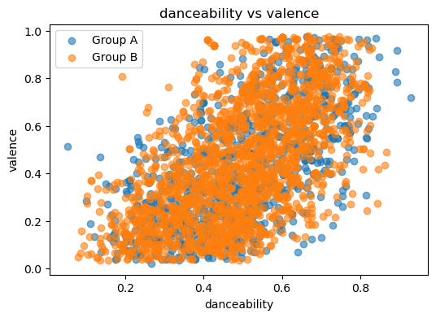

```python
def plot_feature_comparisons(groupA, groupB, comparisons, groupA_label='Group A', groupB_label='Group B'):
    for x_feat, y_feat in comparisons:
        plt.figure(figsize=(6, 4))
        plt.scatter(groupA[x_feat], groupA[y_feat], alpha=0.6, label=groupA_label)
        plt.scatter(groupB[x_feat], groupB[y_feat], alpha=0.6, label=groupB_label)
        plt.xlabel(x_feat)
        plt.ylabel(y_feat)
        plt.title(f"{x_feat} vs {y_feat}")
        plt.legend()
        plt.show()

comparisons = [("acousticness", "energy"), ( "energy", "loudness"), ("danceability","valence" )]
plot_feature_comparisons(groupA,groupB,comparisons)
```

### PCA Feature Contribution Analysis

This function shows the importance (loadings) of each feature to PC1 and PC2. *It's essential to understand what features drive the separation in PCA space*. In this investigation, the feature `"mode"` was **dominant and binary**, misleading PCA interpretation.

```python
def pca_feature_contributions(df, iloc_lower, iloc_upper, n_components=2, sort_by='PC1'):
    features = df.iloc[:, iloc_lower:iloc_upper]
    scaled = MinMaxScaler().fit_transform(features)
    pca = PCA(n_components=n_components)
    pca.fit(scaled)
    loadings = pd.DataFrame(pca.components_.T, columns=[f'PC{i+1}' for i in range(n_components)], index=features.columns)
    return loadings.sort_values(by=sort_by, ascending=False)

pca_f = pca_feature_contributions(df,6,20)
print(pca_f)
```

```
                       PC1       PC2
mode              0.941287 -0.270838
acousticness      0.177116  0.503884
valence           0.092582  0.322209
danceability      0.046262  0.257952
liveness          0.018852 -0.006056
tempo             0.006292 -0.061811
duration_ms      -0.020770 -0.026353
popularity       -0.045738  0.048381
speechiness      -0.046865 -0.120539
loudness         -0.064208 -0.217542
explicit         -0.082406 -0.404737
instrumentalness -0.122890 -0.285855
energy           -0.134029 -0.417181
key              -0.151006  0.118654
```

### Drop Binary Feature "mode"

This critical step removes the misleading `"mode"` binary feature from the dataset. This was the key fix that restored the PCA plot to the expected behavior, *resolving the original mystery of unintended data segmentation*.

```python
del df["mode"]
```

### Re-run Clustering Without "mode"

After removing `"mode"`, the clustering process is repeated on the reduced feature set. This helps **verify whether the new PCA plot better** reflects true genre separability without binary interference.

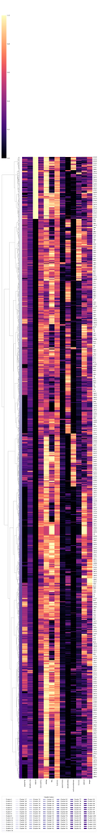

```
   popularity  duration_ms  explicit  danceability  energy  key  loudness  \
0          66       151565     False         0.765   0.497    1    -7.806
1          65        89293     False         0.720   0.422    1   -13.338
2          49       259066     False         0.632   0.651    7    -8.658
3          49       216446     False         0.610   0.420    4   -10.889
4          50       273906     False         0.580   0.330    7   -13.703

   speechiness  acousticness  instrumentalness  liveness  valence    tempo  \
0       0.0402         0.492          0.366000    0.1430    0.457  112.195
1       0.0690         0.474          0.084700    0.1550    0.546  112.219
2       0.0401         0.756          0.000004    0.7260    0.652  119.567
3       0.0462         0.815          0.000000    0.1230    0.553   96.313
4       0.0295         0.596          0.000001    0.0849    0.373  136.408

   cluster
```

[output cut: 45 more lines]

```python
result2 = hierarchical_clustering(df,6,19 )
print(result2)
```

### 🔬 Re-plot PCA After Removing "mode"

This re-visualizes the PCA scatter plot after dropping the "mode" feature. It's expected that this projection no longer artificially separates data solely due to the binary nature of "mode".

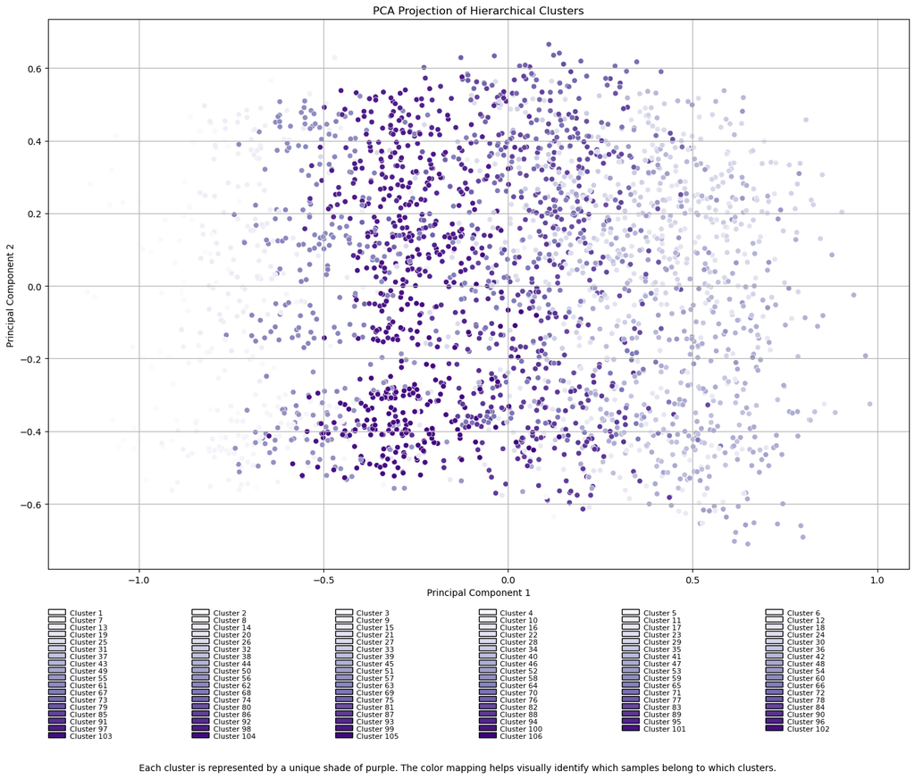

|  | PC1 | PC2 | cluster |
| --- | --- | --- | --- |
| 0 | 0.317817 | -0.460902 | 38 |
| 1 | 0.506695 | -0.451429 | 38 |
| 2 | 0.553200 | 0.084895 | 20 |
| 3 | 0.672430 | -0.223854 | 45 |
| 4 | 0.546521 | 0.038317 | 30 |
| ... | ... | ... | ... |
| 2995 | -0.310477 | -0.375755 | 102 |
| 2996 | -0.379712 | 0.135940 | 100 |
| 2997 | -0.683685 | -0.299595 | 7 |
| 2998 | -0.642556 | 0.053592 | 14 |
| 2999 | -0.509932 | 0.436511 | 59 |

3000 rows × 3 columns

```python
pca_df2 =plot_pca_clusters_with_legend(df,6,19)
pca_df2
```

### Merge and Analyze PCA Groups Again

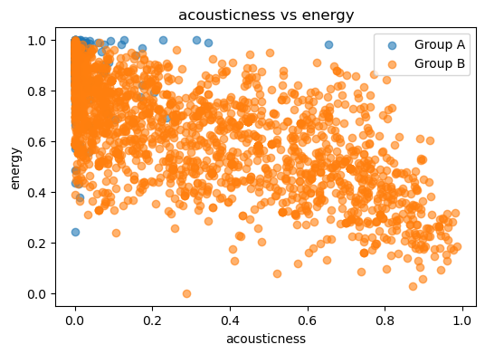

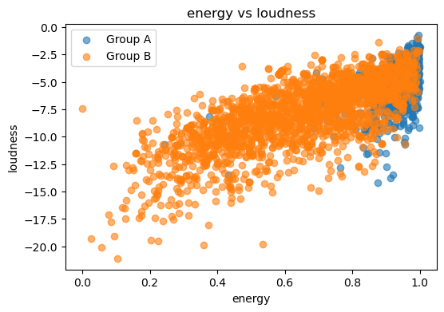

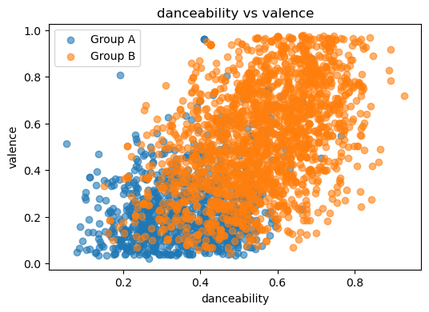

```python
df_cluster_PCA2 = pd.merge(result2, pca_df2, left_index=True, right_index=True)
df_cluster_PCA2.drop(columns=["cluster_y"], inplace=True)
df_cluster_PCA2.reset_index(inplace=True)

pc1_2 = df_cluster_PCA2["PC1"].tolist()
pc2_2 = df_cluster_PCA2["PC2"].tolist()

pc_distances_2 = [get_pca_distance_with_x_sign(x, y) for x, y in zip(pc1_2, pc2_2)]
df_cluster_PCA2["PCA_EuclidianDist(Xsign)"] = pc_distances_2

df_cluster_PCA_gp2 = add_first_boundary_group(df_cluster_PCA2)
df_cluster_PCA_gp2 = pd.merge(df["track_genre"], df_cluster_PCA_gp2, left_index=True, right_index=True)

groupA2 = df_cluster_PCA_gp2[df_cluster_PCA_gp2["1th_Boundary"] == -1]
groupB2 = df_cluster_PCA_gp2[df_cluster_PCA_gp2["1th_Boundary"] == 1]

plot_feature_comparisons(groupA2,groupB2,comparisons)
```

### Final Feature Contributions (Without "mode")

```python
pca_f2 = pca_feature_contributions(df,6,19)
pca_f2
```

|  | PC1 | PC2 |
| --- | --- | --- |
| acousticness | 0.539950 | -0.120650 |
| valence | 0.332354 | 0.165764 |
| danceability | 0.257340 | 0.033381 |
| popularity | 0.026454 | -0.070637 |
| key | 0.023274 | 0.968018 |
| liveness | 0.002107 | -0.016872 |
| duration_ms | -0.032260 | -0.018120 |
| tempo | -0.055981 | 0.066508 |
| speechiness | -0.130314 | 0.009343 |
| loudness | -0.227597 | 0.035397 |
| instrumentalness | -0.314212 | -0.021805 |
| explicit | -0.405121 | -0.048159 |
| energy | -0.441266 | 0.075040 |